# UMAP/t-SNE hybrids

February 17, 2018

Up: [Documentation Home](https://jlmelville.github.io/smallvis/).

This a companion to the experiments I did with [UMAP](https://jlmelville.github.io/smallvis/umap.html). Here I’m going to see if borrowing some of UMAP’s way of doing things affects t-SNE performance measurably. See the previous UMAP page and the [theory](https://jlmelville.github.io/smallvis/theory.html) for details on UMAP. This work was inspired by the release of the [UMAP paper](https://arxiv.org/abs/1802.03426), which shows a very nice result for the COIL-20 data with UMAP. As of this writing, the settings used for that result were not available, so this is an attempt to see if there’s something specific to one of the differences of UMAP from t-SNE that causes that difference, e.g. the method of generating the input our output weights. If so, perhaps t-SNE could produce a result nearly as good, just by borrowing that feature.

By borrowing individual changes from UMAP we can define some new versions of t-SNE:

- SKD t-SNE: Instead of a perplexity-based calibration to generate the input weights, it uses smooth knn distances.
- u-SNE: Instead of the t-distribution to define the output kernel, the UMAP function is $w_{ij} = 1 / \left(1 + ad_{ij}^{2b}\right)$. When using a function like this, both LargeVis and UMAP add a value between `0.001` to `0.1` to the denominator of the resulting gradient to both avoid division by zero and to avoid rather odd-looking results (at least in the way `smallvis` calculates the non-stochastic gradient). But when used with SNE (perhaps due to normalization?) I could get away with a much smaller value, which here is `1e-10`. The default UMAP weight function parameters $a = 1.929$ and $b = 0.7915$ were used.
- CE t-SNE: The fuzzy set cross-entropy is used instead of the KL divergence. In the way it’s defined by UMAP, this adds an extra non-constant term to the cost function.
- UMAP also uses a normalized Laplacian for initialization, but as discussed under [t-SNE initialization](https://jlmelville.github.io/smallvis/init.html), this gives very similar results to using Laplacian Eigenmaps, which in turn doesn’t give very different results on most datasets to just using the scaled PCA result, so we won’t pursue that further here.

## Datasets

See the [Datasets](https://jlmelville.github.io/smallvis/datasets.html) page.

## Settings

For settings, we’ll use two sets. First, the ones given in the [original t-SNE paper](http://www.jmlr.org/papers/v9/vandermaaten08a.html), except instead of random initialization, we’ll use the scaled PCA approach. Also, I’ve doubled the number of iterations allowed from 1000 to 2000 to avoid any problems with convergence with these new methods. We’ll also generate t-SNE results to compare with these variations.

For the second set of results, I’ll set the perplexity to 15, which is closer to the UMAP defaults.

```
iris_usne <- smallvis(iris, scale = FALSE, perplexity = 40, Y_init = "spca", method = list("usne", gr_eps = 1e-10), eta = 100, exaggeration_factor = 4, stop_lying_iter = 50, max_iter = 2000, epoch = 50, tol = 1e-5)

iris_skdtsne <- smallvis(iris, scale = FALSE, perplexity = 40, Y_init = "spca", method = "skdtsne", eta = 100, exaggeration_factor = 4, stop_lying_iter = 50, max_iter = 2000, epoch = 50, tol = 1e-5)

iris_cetsne <- smallvis(iris, scale = FALSE, perplexity = 40, Y_init = "spca", method = "cetsne", eta = 100, exaggeration_factor = 4, stop_lying_iter = 50, max_iter = 2000, epoch = 50, tol = 1e-5)

iris_tsne <- smallvis(iris, scale = FALSE, perplexity = 40, Y_init = "spca", method = "tsne", eta = 100, exaggeration_factor = 4, stop_lying_iter = 50, max_iter = 2000, epoch = 50, tol = 1e-5)
```

## Evaluation

Apart from visualizing the results, the mean neighbor preservation of the k closest neighbors is used to provide a rough quantification of the quality of the result. For the first set of results, with perplexity = 40, k = 40 and is labelled as `mnp@40`. The second set of results with perplexity = 15, k = 15 and is labelled as `mnp@15`.

## Results: Perplexity 40

### iris

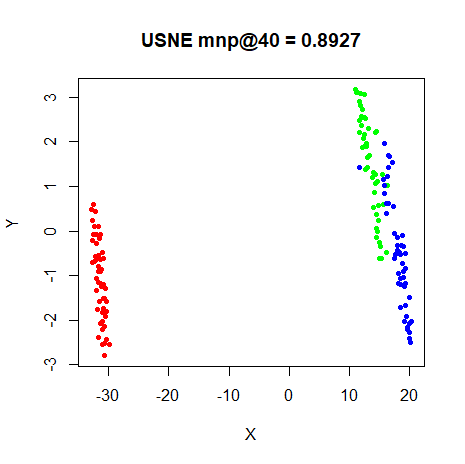

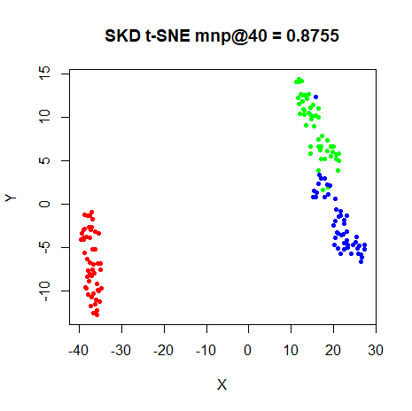

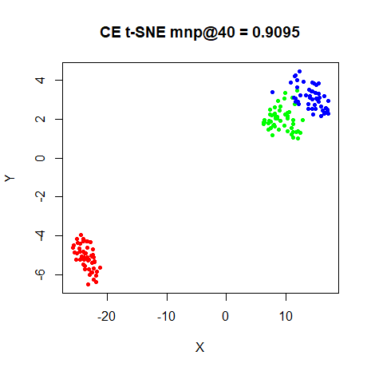

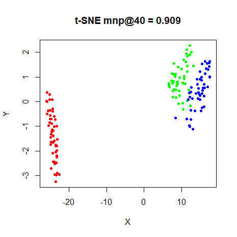

### s1k

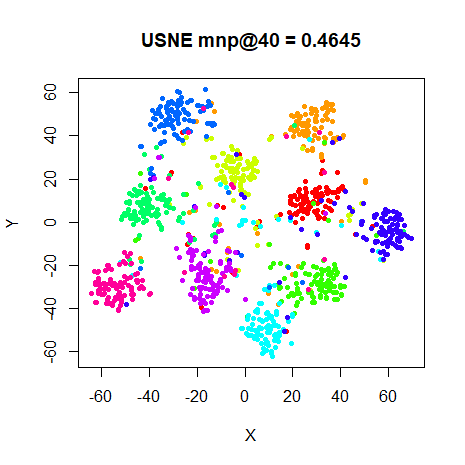

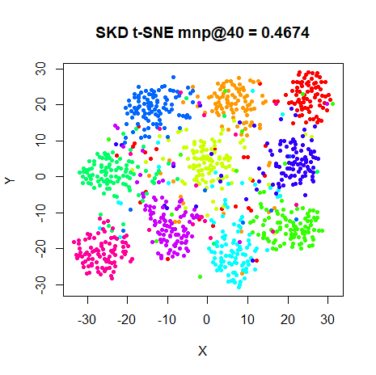

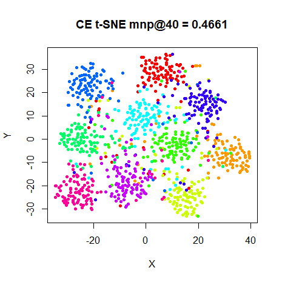

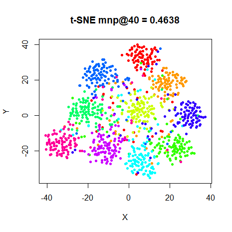

### oli

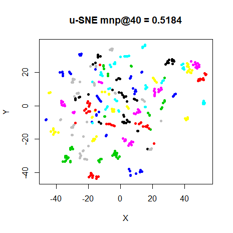

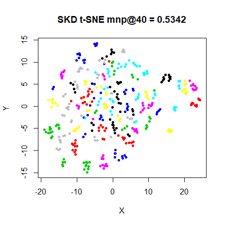

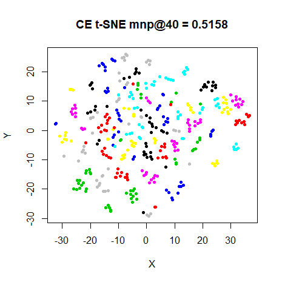

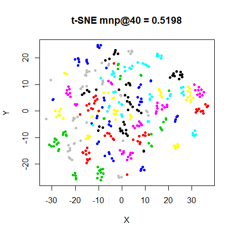

### frey

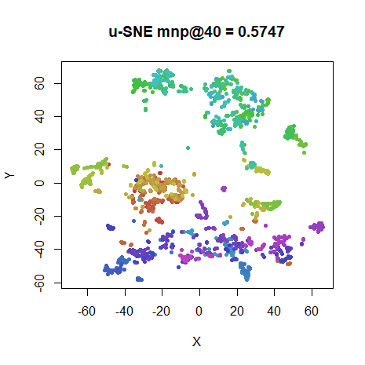

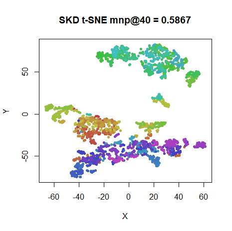

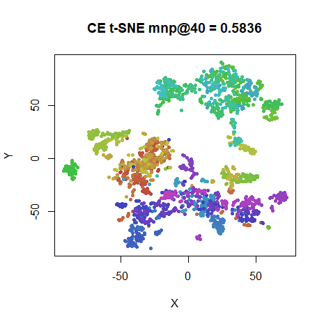

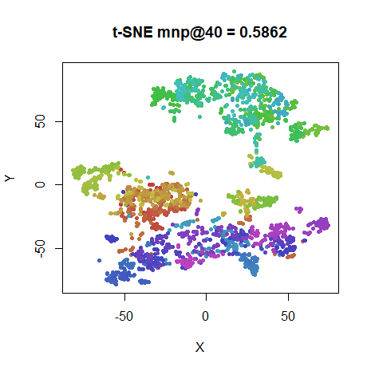

### coil20

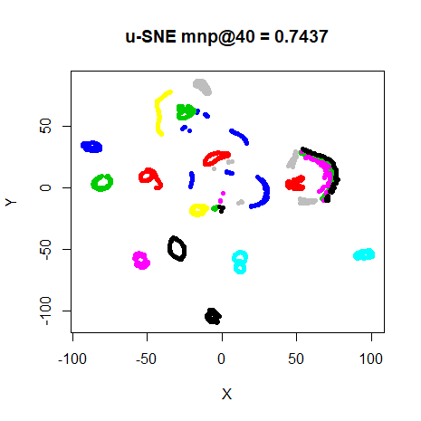

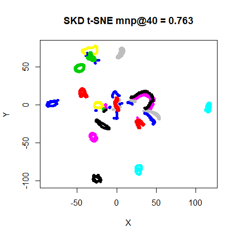

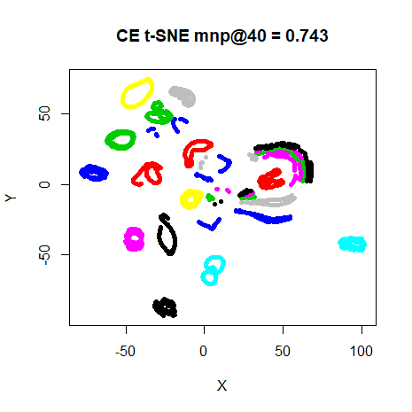

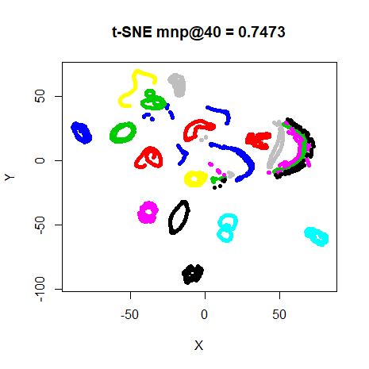

### mnist

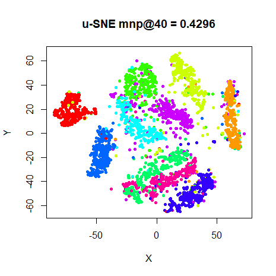

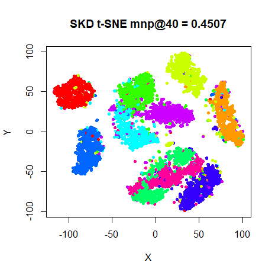

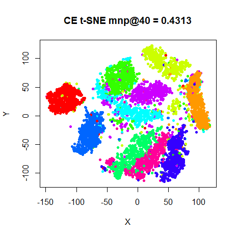

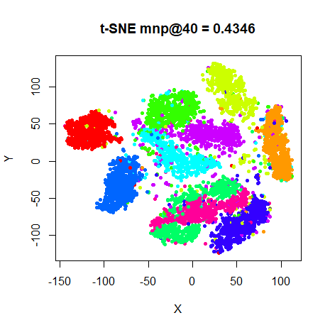

### fashion

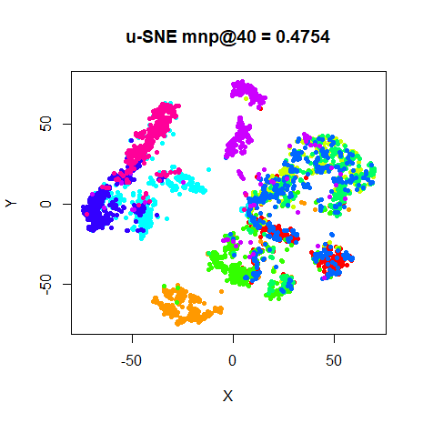

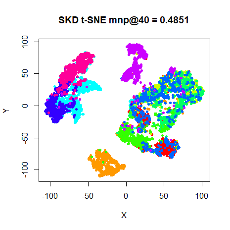

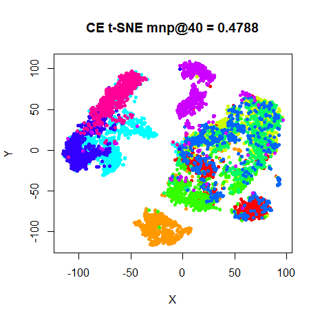

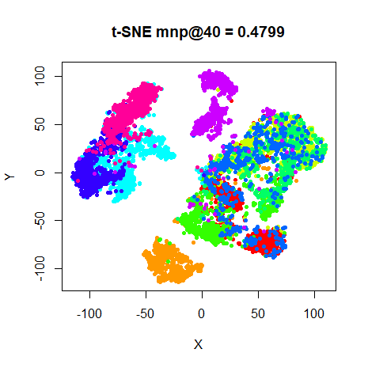

## Results: Perplexity 15

### iris

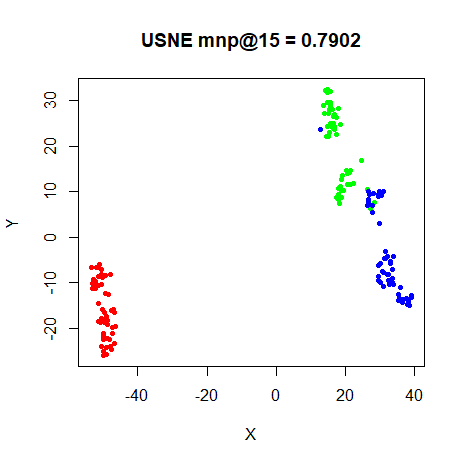

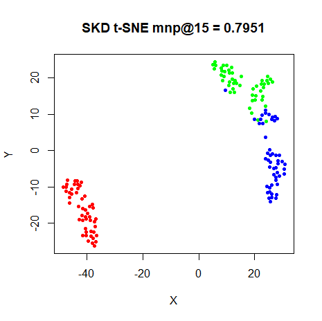

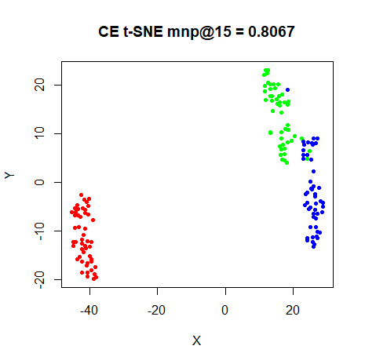

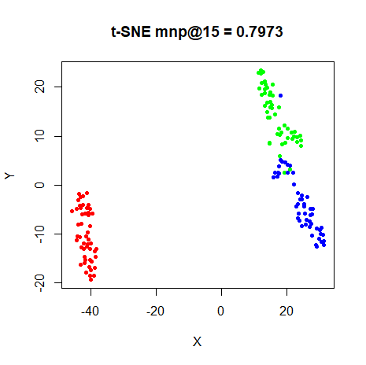

### s1k

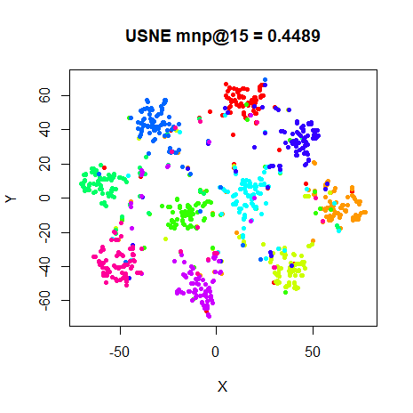

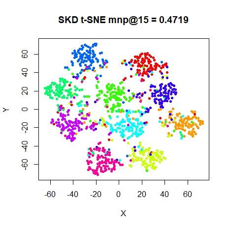

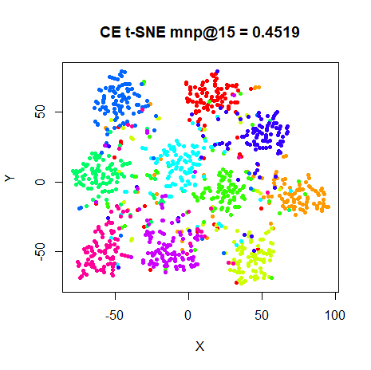

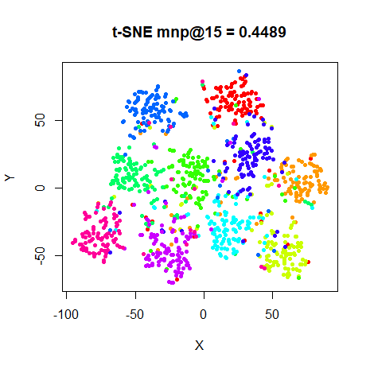

### oli

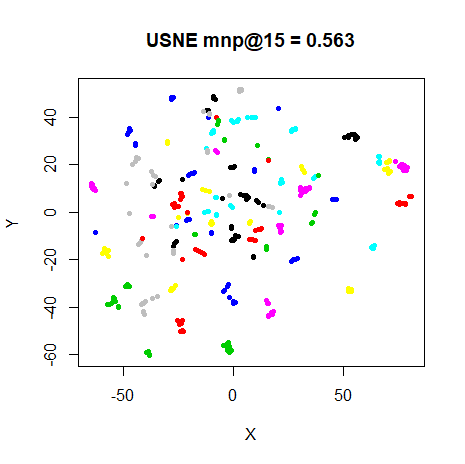

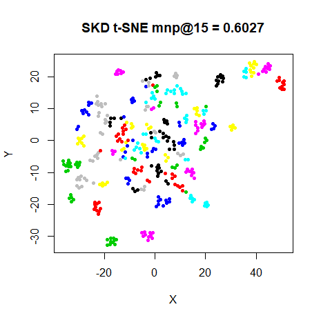

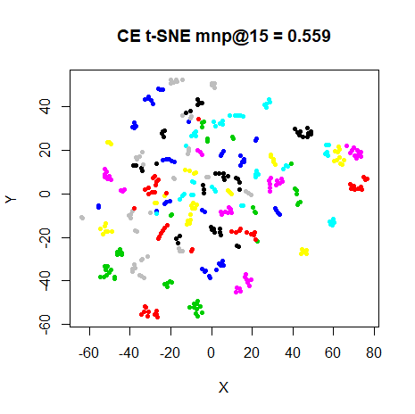

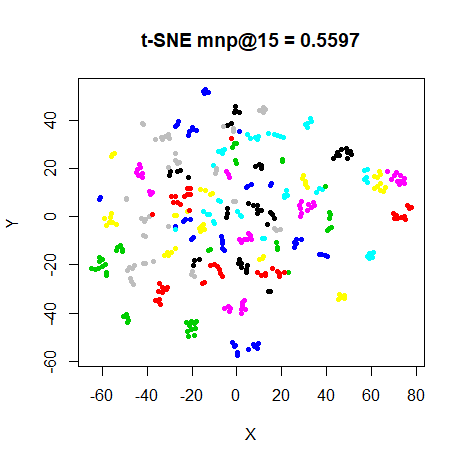

### frey

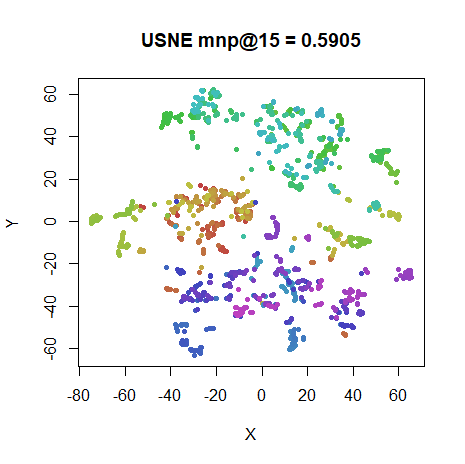

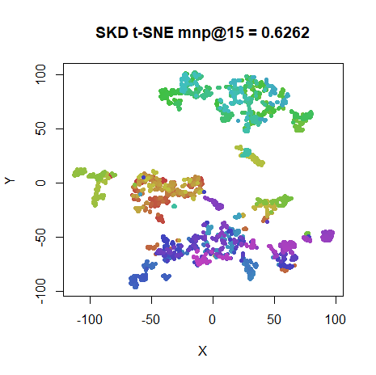

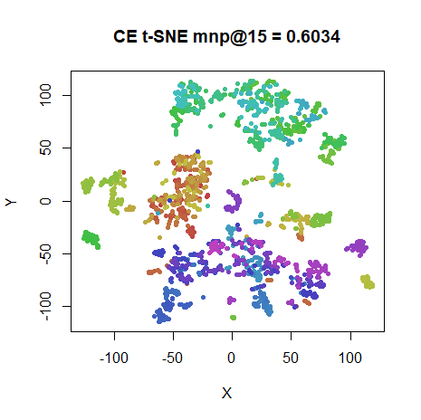

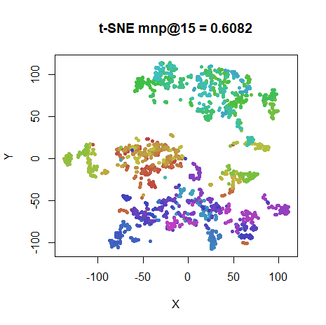

### coil20

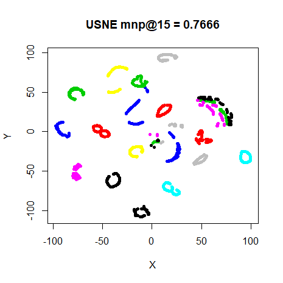

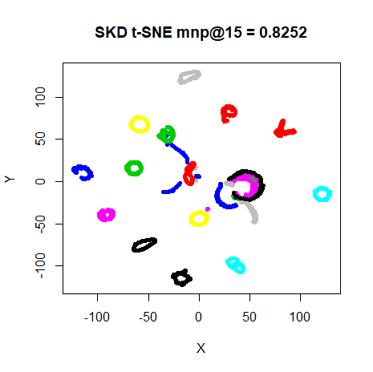

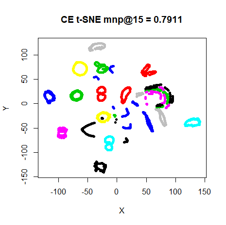

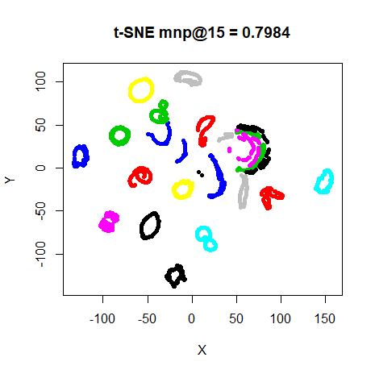

### mnist

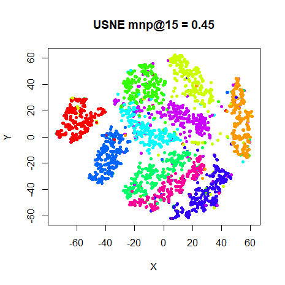

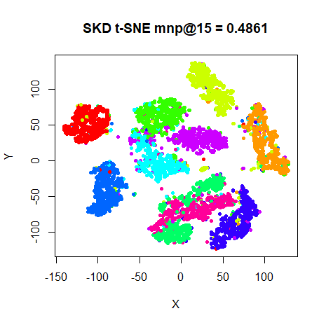

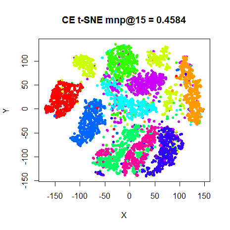

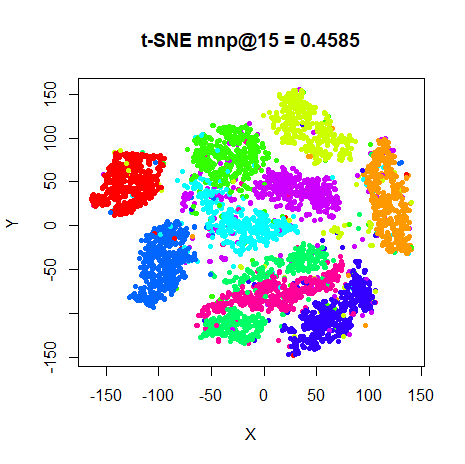

### fashion

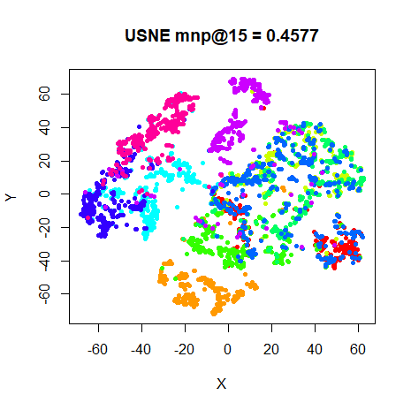

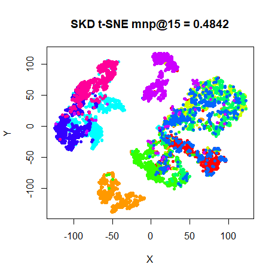

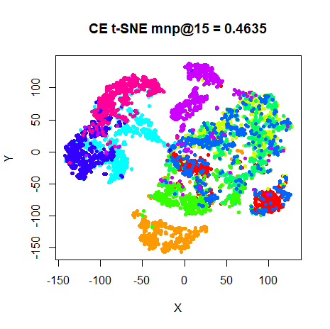

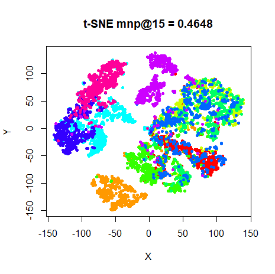